# Week 6 - Midterm Assignment: A Simulation Project

STAT 420, Summer 2021, Alejandro Pimentel (ap41)

```r
library(knitr)
library(kableExtra)
library(dplyr)

format_numerics <- function(data, digits = 2, notation_threshold = 0.00001) {
  # make sure is a data.frame, then format
  if(!is.data.frame(data)){
    data <- as.data.frame(data)
  }
  data %>%
    mutate_if(
      is.numeric,
      function(x) {
        if_else(
          abs(x) < notation_threshold,
          formatC(x, digits = digits, format = "e"),
          formatC(x, digits = digits, format = "f", drop0trailing = FALSE)
        )
      }
    )
}

gen_kable <- function(table_data, add_row_names = TRUE, caption = "", col_names = c(), row_names = c()) {
  f_data <- format_numerics(table_data)
  if(length(col_names) != 0){
    colnames(f_data) <- col_names
  }
  if(length(row_names) != 0){
    rownames(f_data) <- row_names
  }
  f_data %>%
  kable(., format = "html", row.names = add_row_names,
        caption = caption, escape = FALSE) %>%
    kable_styling(bootstrap_options = c("striped", "hover"),
                  full_width = F,
                  font_size = 14,
                  position = "center")
}

fr <- function(nums, digits = 5, notation_threshold = 0.000001) {
  if_else(
    abs(nums) < notation_threshold,
    formatC(nums, digits = digits, format = "e"),
    format(round(nums, digits), nsmall = digits)
  )
}
```

# Simulation Study 1: Significance of Regression

## Introduction

In this simulation study we will investigate the significance of regression test. We will simulate from two different models:

1. The **“significant”** model

$$Y_i = \beta_0 + \beta_1 x_{i1} + \beta_2 x_{i2} + \beta_3 x_{i3} + \epsilon_i$$

where $\epsilon_i \sim N(0, \sigma^2)$ and

- $\beta_0 = 3$,
- $\beta_1 = 1$,
- $\beta_2 = 1$,
- $\beta_3 = 1$.
2. The **“non-significant”** model

$$Y_i = \beta_0 + \beta_1 x_{i1} + \beta_2 x_{i2} + \beta_3 x_{i3} + \epsilon_i$$

where $\epsilon_i \sim N(0, \sigma^2)$ and

- $\beta_0 = 3$,
- $\beta_1 = 0$,
- $\beta_2 = 0$,
- $\beta_3 = 0$.

For both, we will consider a sample size of $25$ and three possible levels of noise. That is, three values of $\sigma$.

- $n = 25$
- $\sigma \in (1, 5, 10)$

Using simulation we will obtain an empirical distribution for each of the following values, for each of the three values of $\sigma$, for both models.

- The **$F$ statistic** for the significance of regression test.
- The **p-value** for the significance of regression test
- **$R^2$**

For each model and $\sigma$ combination, we use $2000$ simulations. For each simulation, we fit a regression model of the same form used to perform the simulation.

The data found in `study_1.csv` has the values of the predictors. These is kept constant for the entirety of this study. The `y` values in this data are a blank placeholder.

## Methods

Read the `csv` file with our samples and take a look to some of them.

```r
library(readr)
study1_data <- read_csv("./study_1.csv")

head(study1_data)
```

```
## # A tibble: 6 x 4
##       y    x1    x2    x3
##   <dbl> <dbl> <dbl> <dbl>
## 1     0 -1.54   3    2.96
## 2     0 -1.61   2.9  2.71
## 3     0 -4.56   2.9  2.62
## 4     0 -2.28   2.5  2.41
## 5     0 -2.76   3    2.77
## 6     0 -3.01   2.9  2.28
```

```r
# Set a seed to have a stable generation of random numbers
birthday = 19820426
set.seed(birthday)
```

First, let’s define the constant values for our simulation.

```r
# Only take the predictor columns x_i
X <- study1_data[, 2:4]
# The beta values for the significant model
sig_betas <- c(3, 1, 1, 1)
# The beta values for the non-significant model
nosig_betas <- c(3, 0, 0, 0)
# The 3 sigma values to use on each model
sigma_1 <- 1
sigma_5 <- 5
sigma_10 <- 10
num_sims <- 2000

# The degrees of freedom provided we know we have 4 parameters in both models
df1 <- length(sig_betas) - 1
df2 <- nrow(study1_data) - length(sig_betas)
```

For the simulations we need to define a few functions.

First, a function to generate the responses $y$. For which we need:

- A matrix with the predictors values.
- A matrix of `p` by 1 where `p` is the number of parameters `beta` in the model.
- A `sigma` to generate noise ($\epsilon$) for the response $y$.

The output is a data frame with all predictors and `y` values added.

```r
generate_mlr_data <- function(X, betas, sigma = 1) {
  n <- nrow(X)
  epsilon <- rnorm(n = n, mean = 0, sd = sigma)
  X_full <- as.matrix(cbind(1, X))
  X$y <- (X_full %*% betas) + epsilon
  as.data.frame(X)
}
```

Next, we need a function that runs a number of simulations with fixed $\beta_i$ values and $\sigma$. For each `fitted model` the function extracts:

- The **$F$ statistic** for the significance of regression test.
- The **p-value** for the significance of regression test
- **$R^2$**

```r
loop_simulation <- function (X, betas, num_simulations = 2000, sigma = 1) {
  fstats <- rep(0, num_simulations)
  pvals <- rep(0, num_simulations)
  r2s <- rep(0, num_simulations)
  for (i in 1:num_simulations) {
    sim_data <- generate_mlr_data(X, matrix(betas), sigma)
    sim_model <- lm(y ~ ., data = sim_data)
    ft <- unname(summary(sim_model)$fstatistic)
    fstats[i] <- ft[1]
    # ft[1] = F-value, ft[2] = p - q, ft[3] = n - p
    pvals[i] <- 1 - pf(abs(ft[1]), df1 = ft[2], df2 = ft[3])
    #print(anova(lm(y ~ 1, data = sim_data),sim_model)[2, "Pr(>F)"])
    #print("****************")
    r2s[i] <- summary(sim_model)$r.squared
  }
  list(
    fstats = fstats,
    pvals = pvals,
    r2s = r2s
    )
}
```

We are set to run the 6 simulations, the code below does that for each model and $\sigma$.

```r
# Simulations for the significant model
signif_1 <- loop_simulation(X, sig_betas, num_simulations = num_sims, sigma_1)
signif_5 <- loop_simulation(X, sig_betas, num_simulations = num_sims, sigma_5)
signif_10 <- loop_simulation(X, sig_betas, num_simulations = num_sims, sigma_10)

# Simulations for the non-significant model
nosignif_1 <- loop_simulation(X, nosig_betas, num_simulations = num_sims, sigma_1)
nosignif_5 <- loop_simulation(X, nosig_betas, num_simulations = num_sims, sigma_5)
nosignif_10 <- loop_simulation(X, nosig_betas, num_simulations = num_sims, sigma_10)
```

## Results

Here we present a collection of graph to analyze the simulation results. To keep things DRY I define a function that shows:

- A histogram of the empirical values obtained in the simulation.
- The `true` curve of the distribution (when the distribution is known).

```r
graph_helper <- function(simuldata, sigma, dist_curve = "",
                         color, title, auto_xlim = TRUE) {
  if(auto_xlim) {
    hist(simuldata, probability = TRUE, breaks = 15,
       xlab = title,
       main = paste(title," ( sigma =", sigma,")"),
       col = color,
       border = "aliceblue")
  } else {
    hist(simuldata, probability = TRUE, breaks = 15,
       xlab = title,
       xlim = c(-1, max(simuldata)),
       main = paste(title," ( sigma =", sigma,")"),
       col = color,
       border = "aliceblue")
  }
  if(dist_curve == "f") {
    curve(df(x, df1 = df1, df2 = df2),
        col = "darkorange",
        add = TRUE, lwd = 3
        )
  }

  if(dist_curve == "unif") {
    curve(dunif(x),
      col = "darkorange",
      add = TRUE, lwd = 3
      )
  }

  if(dist_curve != "") {
    legend("topright", c("Empirical", "Real"),
         lty = c(1, 2),
         lwd = 3,
         col = c(color, "darkorange"))
  }
}
```

### Set of graphs for F-statistic distributions

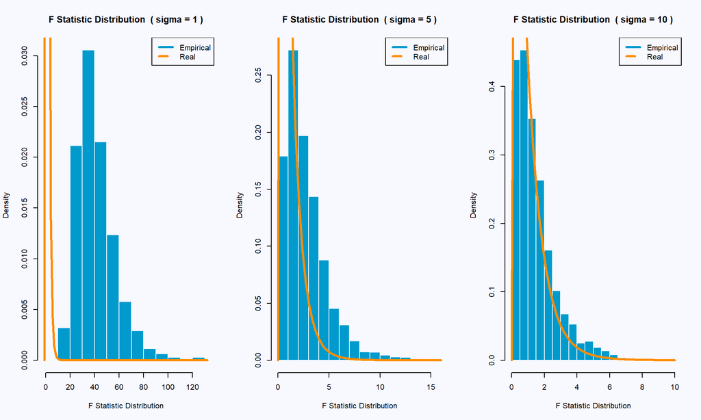

```r
par(mfrow=c(1, 3), bg="ghostwhite")
title <- "F Statistic Distribution"
graph_helper(signif_1$fstats, sigma_1, "f", color = "deepskyblue3", title,
             auto_xlim = FALSE)
graph_helper(signif_5$fstats, sigma_5, "f", color = "deepskyblue3", title)
graph_helper(signif_10$fstats, sigma_10, "f", color = "deepskyblue3", title)
```

**Graph 1.1 - F Statistics for the `significant model` on each $\sigma$**

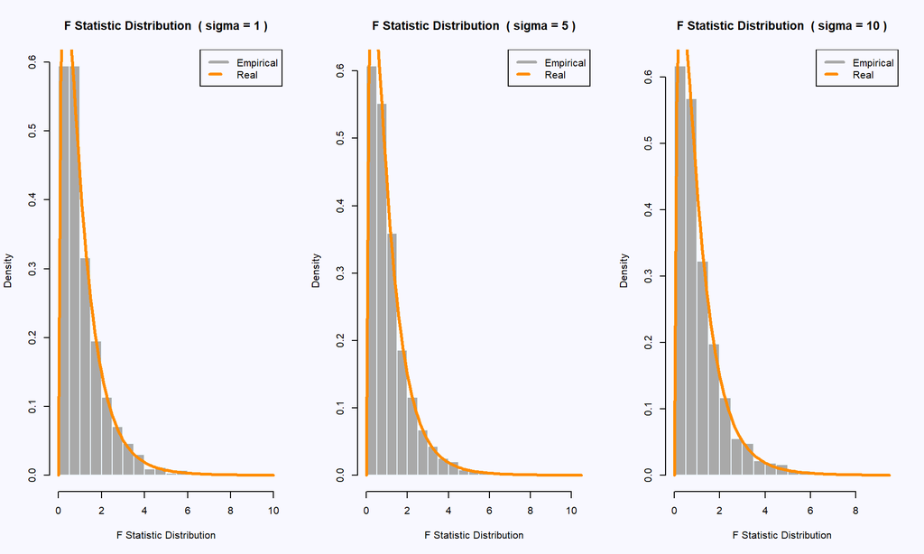

```r
par(mfrow=c(1, 3), bg="ghostwhite")
title <- "F Statistic Distribution"
graph_helper(nosignif_1$fstats, sigma_1, "f", color = "darkgray", title)
graph_helper(nosignif_5$fstats, sigma_5, "f", color = "darkgray", title)
graph_helper(nosignif_10$fstats, sigma_10, "f", color = "darkgray", title)
```

**Graph 1.2 - F Statistics for the `non-significant model` on each $\sigma$**

### Set of graphs for p-value distributions

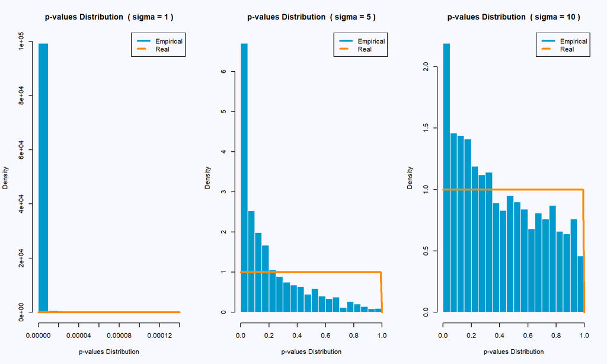

```r
par(mfrow=c(1, 3), bg="ghostwhite")
title <- "p-values Distribution"
graph_helper(signif_1$pvals, sigma_1, "unif", color = "deepskyblue3", title)
graph_helper(signif_5$pvals, sigma_5, "unif", color = "deepskyblue3", title)
graph_helper(signif_10$pvals, sigma_10, "unif", color = "deepskyblue3", title)
```

**Graph 1.3 - p-values for the `significant model` on each $\sigma$**

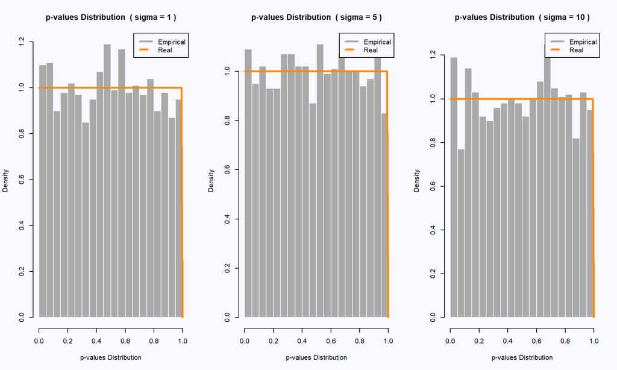

```r
par(mfrow=c(1, 3), bg="ghostwhite")
title <- "p-values Distribution"
graph_helper(nosignif_1$pvals, sigma_1, "unif", color = "darkgray", title)
graph_helper(nosignif_5$pvals, sigma_5, "unif", color = "darkgray", title)
graph_helper(nosignif_10$pvals, sigma_10, "unif", color = "darkgray", title)
```

**Graph 1.4 - p-values for the `non-significant model` on each $\sigma$**

### Set of graphs for $R^2$ distributions

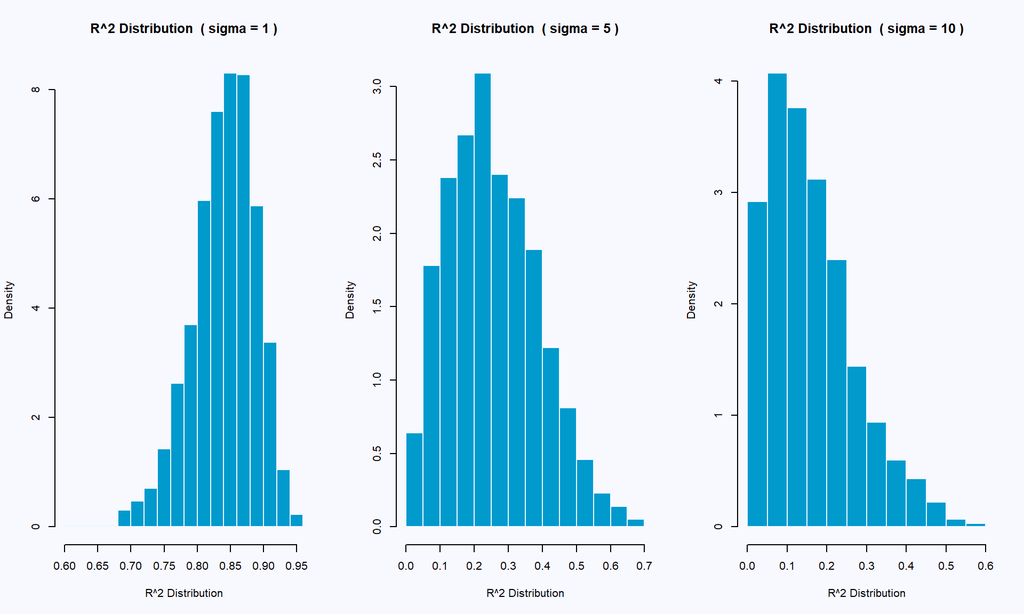

```r
par(mfrow=c(1, 3), bg="ghostwhite")
title <- "R^2 Distribution"
graph_helper(signif_1$r2s, sigma_1, color = "deepskyblue3", title = title)
graph_helper(signif_5$r2s, sigma_5, color = "deepskyblue3", title = title)
graph_helper(signif_10$r2s, sigma_10, color = "deepskyblue3", title = title)
```

**Graph 1.5 - $R^2$ for the `significant model` on each $\sigma$**

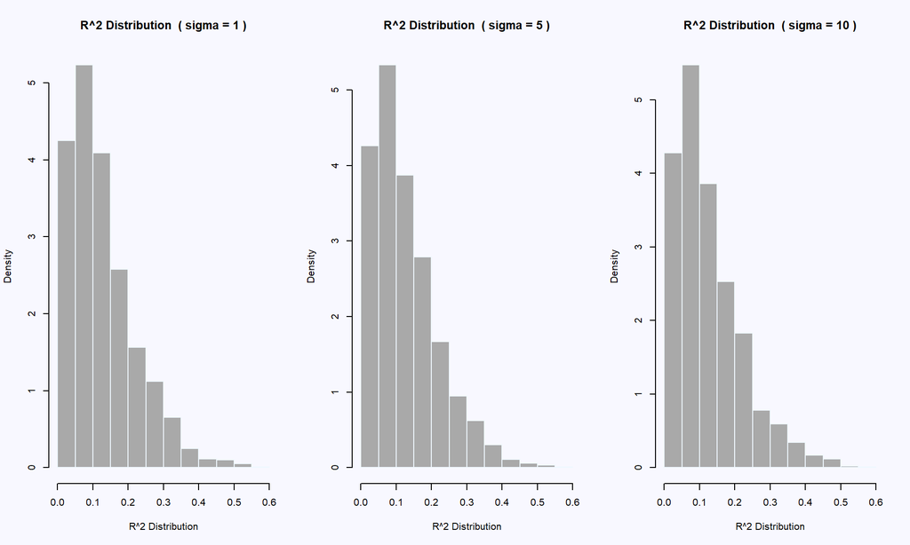

```r
par(mfrow=c(1, 3), bg="ghostwhite")
title <- "R^2 Distribution"
graph_helper(nosignif_1$r2s, sigma_1, color = "darkgray", title = title)
graph_helper(nosignif_5$r2s, sigma_5, color = "darkgray", title = title)
graph_helper(nosignif_10$r2s, sigma_10, color = "darkgray", title = title)
```

**Graph 1.6 - $R^2$ for the `non-significant model` on each $\sigma$**

## Discussion

**We expect empirical F-values to follow an F distribution under $H_0$**

In this case the F-distribution has 3 and 21 degrees of freedom, we can see in the curve in orange for graphs `1.1` (significant model) and `1.2` (non-significant model).

Also, in the case of the significant model, when the noise is low ($\sigma=1$), the F-values from the simulation are relatively high moving away from the real curve. This translates to lower `p-values` and more successful `Rejections of the Null Hypothesis` which is what we expected since we know $\beta_i \neq 0$.

As $\sigma$ increases, the F-values become smaller and the empirical distribution resembles the the real curve more and more. This makes more likely to `Fail to Reject the Null Hypothesis`.

In the case of the `non-significant model`, we expect to `Fail to Reject the Null Hypothesis` as much as we can, since we know $\beta_i = 0$. Regardless of the level of noise, the empirical distribution is close to the real curve.

**We expect the p-values to follow a uniform distribution under $H_0$**

From `Graph 1.4` (non-significant model) we see the empirical distribution follows a `uniform distribution`, this is expected as in this case we know we should `Fail To Reject the Null Hypothesis`. So for any reasonable $\alpha$, it is likely that $\text{p-value} > \alpha$

As we observed for the F-values, we have a similar relation between the p-values distribution and the amount of noise $\sigma$. For the significant model when $\sigma=1$ we expect many small p-values so that is more likely to `Reject the null Hypothesis`. That is in fact the case in the first plot in `Graph 1.3`, there is high density of very small p-values.

The following table summarizes the previous idea (given $\alpha=0.05$):

- For the significant model the ratio of `Rejections of $H_0$` depends on $\sigma$.
- While for the non-significant model we observed a very small ratio of `Rejections of $H_0$`.

```r
rejections <- data.frame(
  row.names = c("sigma=1", "sigma=5", "sigma=10"),
  "significant model" = c(mean(signif_1$pvals < 0.05),
                                       mean(signif_5$pvals < 0.05),
                                       mean(signif_10$pvals < 0.05)),
  "non-significant model" = c(mean(nosignif_1$pvals < 0.05),
                                              mean(nosignif_5$pvals < 0.05),
                                              mean(nosignif_10$pvals < 0.05))
)

gen_kable(rejections,
          col_names = c("significant model", "non-significant model"),
          caption = "Proportion of Rejections of the Null Hypothesis, alpha=0.05")
```

Proportion of Rejections of the Null Hypothesis, alpha=0.05

|  | significant model | non-significant model |
| --- | --- | --- |
| sigma=1 | 1.00 | 0.06 |
| sigma=5 | 0.34 | 0.05 |
| sigma=10 | 0.11 | 0.06 |

**For the significant model, $R^2$ tends to be lower as $\sigma$ increases**

Recall that the `Coefficient of Determination` $R^2$ is defined as:

$$\begin{aligned}
R^2 &= \frac{\text{SSReg}}{\text{SST}} = \frac{\sum_{i=1}^{n}(\hat{y}_i - \bar{y})^2}{\sum_{i=1}^{n}(y_i - \bar{y})^2}
\end{aligned}$$

Our estimates $\hat{y}_i$ are likely farther from the real mean of the response $\bar{y}$ as we introduce more noise. That is, `SSReg` is smaller resulting in an also smaller $R^2$ value.

`Graph 1.5` (significant model) shows how $R^2$ distribution goes from left skewed to right skewed. We say then that the amount of variation explained by the regression model is reduced as we introduce more noise $\epsilon$

In the case of the `non-significant model` we expect low $R^2$ values regardless of the level of noise. In other words, the non-significant model is not explaining the variation of the response as expected since we know $\beta_i = 0$. `Graph 1.6` shows right skewed distributions due to a low values of $R^2$.